# true

## Optimization

where $(x)_{+}$ is shorthand for max(x,0) and $s^{t}$ is the step size. Henceforth, $\lambda$ is assumed to encompass both the penalty and the step size $s^{t}$. This procedure is only used to update parameters that are subject to penalty. Non-penalized parameters are updated only using step 1 from above.

# Types of Penalties

Outside of both ridge and lasso penalties, a whole host of additional forms of regularization exist.

## Elastic Net

Most notably, the elastic net (Zou and Hastie 2005) encompasses both the ridge and lasso, reaching a compromise between both through the addition of an additional parameter $\alpha$, manifesting itself as

$$P_{enet}(\theta_{j}) = 0.5(1-\alpha)\| \theta_{j} \|_{2} + \alpha\| \theta_{j} \|_{2}$$

with a soft-thresholding update of
$$S(\theta_{j})=
\begin{cases}
0,& |\theta_{j}| < \alpha\lambda\\
\frac{sgn(\theta_{j})(|\theta_{j}|-\alpha\lambda)}{1+(1-\alpha)\lambda}, & |\theta_{j}|\geq\alpha\lambda
\end{cases}$$

When $\alpha$ is zero, ridge is performed, and conversely when $\alpha$ is 1, lasso regularization is performed. This method harnesses the benefits of both methods, particularly when variable selection is warranted (lasso), but there may be collinearity between the variables (ridge).

## Adaptive Lasso

In using lasso penalties, difficulties emerge when the scale of variables differ dramatically. By only using one value of $\lambda$, this can add appreciable bias to the resulting estimates (e.g. Fan and Li 2001). One method proposed for overcoming this limitation is the adaptive lasso (Zou 2006). Instead of penalizing parameters directly, each parameter is scaled by the un-penalized estimated (MLE parameter estimates in SEM). The adaptive lasso results in:
$$F_{alasso} = F_{ML} + \lambda \| \theta_{ML}^{-1} * \theta_{pen} \|_{1}$$
with, following the same form for the lasso, the soft-thresholding update is:

$$S(\theta_{j})= sign(\theta_{j})(|\theta_{j}|-\frac{\lambda}{2|\theta_{j}|})_{+}$$
In this, larger penalties are given for non-significant (smaller) parameters, limiting the bias in estimating larger, significant parameters. Note that one limitation of this approach for SEM models is that the model needs to be estimable with MLE. Particularly for models with large numbers of variables, in relation to sample size, this may not be possible.

## Smoothly Clipped Absolute Deviation Penalty

The SCAD takes the form of:

$$pen_{\lambda,\gamma}(\theta_{j}) = \lambda \big\{I(\theta_{j}\leq\lambda) + \frac{(\gamma \lambda-0)_{+}}{(\gamma-1)\lambda}I(\theta_{j}>\lambda)\big\}$$

with a soft-thresholding update of
$$S(\theta_{j})=
\begin{cases}
S(\theta_{j},\lambda),& |\theta_{j}| \geq 2\lambda\\
\frac{\gamma-1}{\gamma-2}S(\theta_{j},\frac{\lambda\gamma}{\gamma-1}), & 2\lambda < |\theta_{j}|\leq\alpha\lambda\\
\theta_{j} & |\theta_{j}| > \lambda \gamma
\end{cases}$$

for $\gamma > 2$. As the the penalty in equation 11 is non-convex (as is the MCP), this makes the computation more difficult. However, in the context of SEM this can be seen as less problematic, as equation 3 is also non-convex.

## Minimax Concave Penalty

Zhang (2010) proposed the minimax concave penalty:

$$pen_{\lambda,\gamma}(\theta_{j}) = \lambda\bigg(|\theta_{j}|-\frac{\theta_{j}^{2}}{2\lambda\gamma}\bigg)I(|\theta_{j}|<\lambda\gamma) +\frac{\lambda^{2}\gamma}{2}I(|\theta_{j}|\geq \lambda\gamma)$$

with a soft-thresholding update of
$$S(\theta_{j})=
\begin{cases}
\frac{\gamma}{\gamma-1}S(\theta_{j},\lambda),& |\theta_{j}| \leq \lambda\gamma\\
\theta_{j} & |\theta_{j}| > \lambda \gamma
\end{cases}$$

# Implementation

RegSEM is implemented as the package (Jacobucci 2017) in the statistical environment (R Core Team 2017). To estimate the maximum likelihood fit of the model, uses (RAM; J. J. McArdle and McDonald 1984, McArdle (2005)) notation to derive an implied covariance matrix. The parameters of each SEM are translated into three matrices: the (), the (; directed paths; e.g. factor loadings or regressions), and the (; undirected paths; e.g. covariances or variances). See Jacobucci, Grimm, and McArdle (2016) for more detail on RAM notation.

```r
library(lavaan)
mod <- "
f1 = ~ NA*x1 + x2 + x3 + x4 + x5 + x6 + x7 + x8 + x9
f1~~1*f1
"
out <- cfa(mod,HolzingerSwineford1939)
```

After a model is run in lavaan, using or any of the wrapper functions for fitting a model (i.e. , , or ), the object is then used by the regsem package to translate the model into RAM notation and run using one of three functions: , , or . The function runs a model with one penalty value, whereas does the same but allows for the use of random starting values. However, the main function is as this not only runs the model, but runs it across a vector of varying penalty values. For instance in the above one-factor model, each of the factor loadings can be tested with lasso penalties to determine whether each indicator is a necessary component of the latent factor:

```r
library(regsem)
extractMatrices(out)["A"]
out.reg <- cv_regsem(out, type="lasso",
                    pars_pen=c(1:9),n.lambda=15,jump=.05)
```

In this, the function allows the user to examine at how the lavaan model is translated into RAM matrices. Further, by looking at the matrix, the parameter numbers corresponding to the factor loadings of interest for regularization can be identified. For this model, the factor loadings represent parameter numbers one through nine, of which we pass directly to the argument of the function (if then all directed effects, outside of intercepts, are penalized). Additionally, we pass the arguments of how many values of penalty we want to test (), how much the penalty should increase for each model (), and finally that lasso estimation is used ().

The object contains two components, has the parameter estimates for each of the 15 models,

```r
head(round(out.reg[[1]],2),5)
```

```
##      f1 -> x1 f1 -> x2 f1 -> x3 f1 -> x4 f1 -> x5 f1 -> x6 f1 -> x7
## [1,]     0.51     0.26     0.25     0.98     1.08     0.92     0.20
## [2,]     0.41     0.17     0.17     0.89     0.98     0.83     0.12
## [3,]     0.33     0.10     0.10     0.83     0.91     0.77     0.06
## [4,]     0.27     0.04     0.04     0.78     0.87     0.72     0.01
## [5,]     0.21     0.00     0.00     0.75     0.83     0.69     0.00
##      f1 -> x8 f1 -> x9 x1 ~~ x1 x2 ~~ x2 x3 ~~ x3 x4 ~~ x4 x5 ~~ x5
## [1,]     0.20     0.31     1.10     1.31     1.21     0.38     0.49
## [2,]     0.13     0.23     1.11     1.32     1.22     0.38     0.48
## [3,]     0.08     0.17     1.13     1.33     1.23     0.38     0.47
## [4,]     0.03     0.12     1.15     1.35     1.25     0.38     0.46
## [5,]     0.00     0.07     1.18     1.36     1.26     0.39     0.46
##      x6 ~~ x6 x7 ~~ x7 x8 ~~ x8 x9 ~~ x9
## [1,]     0.36     1.15     0.98     0.92
## [2,]     0.36     1.15     0.99     0.93
## [3,]     0.36     1.16     1.00     0.94
## [4,]     0.37     1.17     1.01     0.96
## [5,]     0.38     1.18     1.02     0.97
```

while looks like:

```r
round(out.reg[[2]],2)
```

```
##       lambda conv rmsea     BIC
##  [1,]   0.00    0  0.19 7805.18
##  [2,]   0.05    0  0.19 7815.39
##  [3,]   0.10    0  0.20 7840.59
##  [4,]   0.15    0  0.21 7875.84
##  [5,]   0.20    0  0.20 7886.15
##  [6,]   0.25    0  0.21 7911.82
##  [7,]   0.30    0  0.21 7934.45
##  [8,]   0.35    0  0.22 7960.67
##  [9,]   0.40    0  0.23 7991.03
## [10,]   0.45    0  0.23 8009.42
## [11,]   0.50    0  0.23 8034.81
## [12,]   0.55    0  0.24 8069.49
## [13,]   0.60    0  0.29 8360.54
## [14,]   0.65    0  0.29 8360.53
## [15,]   0.70    0  0.29 8360.52
```

In this, the user can examine the penalty (lambda), whether the model converged (“conv”=0), and the fit of each model. By default, two fit indices are output, both the root mean square error of approximation (RMSEA; Steiger and Lind 1980), and the Bayesian information criteria (BIC; Schwarz 1978). Both the RMSEA and BIC take into account the degrees of freedom of the model, an important point for model selection in the presence of lasso penalties (and other penalties that set parameters to zero). Based on work done on degrees of freedom for lasso regression, as Zou, Hastie, and Tibshirani (2007) proved that the number of nonzero coefficients is an unbiased estimate of the degrees of freedom for regression. As the penalty increases, select parameter are set to zero, thus the degrees of freedom increases, which for fit indices that include the degrees of freedom in the calculation, means that although the likelihood of the model may only get worse (increase), both the RMSEA and BIC can improve (decrease) due to the impact of increased degrees of freedom.

Instead of examining the output matrix of parameter estimates, users also have the option to plot the trajectory of each of the penalized parameters. This is accomplished with , resulting in:

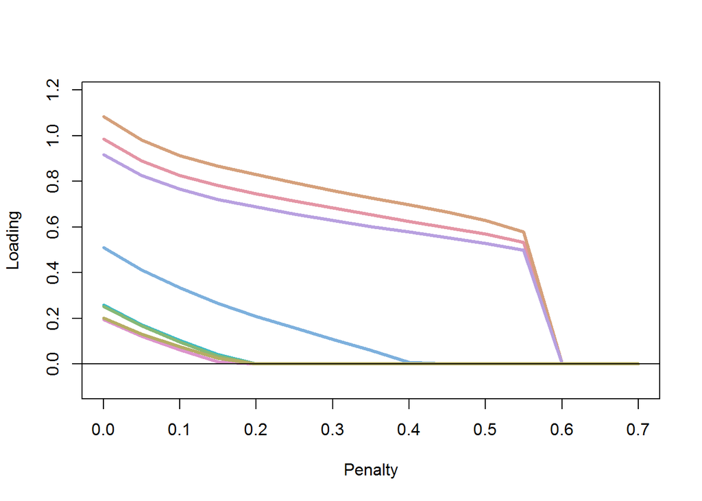

```r
plot_cv(out.reg,pars=1:9)
```

After a final model (penalty) is chosen, users have the option either just use the output from , or the final model can be re-run with either or to attain additional information. In the model above, the best fitting penalty, according to the BIC, is $\lambda=0$. However, for demonstration purposes, we can choose a penalty of 0.2. With this, the model is re-run with

```r
mod.out <- regsem(out, type="lasso", pars_pen=c(1:9),lambda=0.2)
#summary(mod.out)
```

Note that the arguments used above correspond to the same arguments in . However, has additional optional arguments corresponding to the number or random starts to try. Additional fit indices can be attained through the function.

```r
fit_indices(mod.out)
```

```
## $Data_Type
## [1] "Train"
##
## $fits
##           Fmin         varFit              p          chisq        p.chisq
##        0.69087        0.00000        9.00000      415.90286        0.00000
##           nfac             df           npar              N baseline.chisq
##        1.00000       31.00000       14.00000      301.00000      918.85159
##    baseline.df           logl            ncp          rmsea    rmsea.lower
##       36.00000    -3903.04360        1.28301        0.20344        0.18598
##    rmsea.upper     rmsea.pval            CFI            TLI            BIC
##             NA        0.00000        0.56402        0.49370     7885.98674
##            AIC           CAIC         EBIC.5        EBIC.25
##     7834.08719     7983.11043     8051.12157     8017.06459
```

These same fit measures can be accessed through , through changing the defaults with the argument. Finally, instead of assessing these fit indices on the same sample that the models were run on, a holdout dataset could be used. This can be done two ways: either with or with and specifying the name of the holdout covariance matrix.

# Comparison

```r
mod1 <- "
i =~ 1*x1 + 1*x2 + 1*x3 + 1*x4
s =~ 0*x1 + 1*x2 + 2*x3 + 3*x4
i ~ c1 + c2 + c3 + c4 + c5 + c6 + c7 + c8 + c9 + c10
s ~ c1 + c2 + c3 + c4 + c5 + c6 + c7 + c8 + c9 + c10
"
lav.growth <- growth(mod1,dat,fixed.x=T)
```

To compare different types of penalties in , it requires a different specification of the argument. The options currently include maximum likelihood (), ridge (), lasso (), adaptive lasso (), elastic net (), SCAD (), and MCP (). For the elastic net, there is an additional hyperparameter, $\alpha$ that controls the tradeoff between ridge and lasso penalties. This is specified as , which has a default of 0.5. Additionally, both the SCAD and MCP have the additional hyper parameter of $\gamma$, which is specified as and defaults to 3.7 per Fan and Li (2001).

# Discussion

Broadly speaking, there is a growing amount of research into the integration between data mining methods and latent variable models. Specifically, beyond RegSEM, this has taken the form of item response theory and regularization (Sun et al. 2016), pairing both structural equation models with decision trees (Brandmaier et al. 2013), exploratory psychological network analaysis (e.g. Epskamp, Rhemtulla, and Borsboom 2016), along with many others. The amount of pairing between methods that have generally been housed in separate camps will only increase into the future. This type of research will be facilitated by the general upsurge in the creation of open source software that gives users a general framework to test models. This was the motivation behind creating the package in that users can estimate models ranging from simple factor analysis models, to latent longitudinal models with few to many time points, and finally to models with a large number of latent and observed variables. The use of regularization allows for the estimation of much larger structural equation models than before. Specifically, given that latent variables, as discussed in this article, are more commonly used in the social and behavioral sciences, sample sizes are generally not large. To estimate large models with small sample sizes invites increasing amounts of bias, and as demonstrated with the simulated data in this paper. Regularization can be used to reduce the complexity of the model, thus decreasing both the bias and variance.

With highly constrained structural equation models, achieving model convergence can be particularly problematic in using . For instance, with the latent change score model (McArdle and Hamagami 2001), Bayesian regularization methods have less difficulty in reaching convergence across chains (Jacobucci and Grimm 2017). With the recent advent of additional sparsity inducing priors, along with new forms of software such as Stan (Carpenter et al. 2016), for some models it may be more appropriate to use these Bayesian regularization methods over their frequentist counterparts. In the realm of Bayesian regularization for structural equation models, although some research exists (Feng, Wu, and Song 2017), much more is warranted.

Future research with should focus on a number of avenues. One is comparing the different forms of regularization, delineating which method may be best in which setting. Additionally, as structural equation models become larger, with the advent of much larger datasets, computational speed will become a principal concern. Although 40 penalties in the models tested above can be run in a matter of seconds on a standard laptop, larger models can take much longer. To handle this, future implementation with will test the inclusion of different types of optimization, specifically testing whether computation of the Hessian (or approximate Hessian) can reduce the number of optimization steps.

## Conclusion

This paper provided a brief overview on the use of the package as an implementation of regularized structural equation model. Because structural equation modeling encompasses a wide array of latent variable models, the package was created as a general package for including different forms of regularization into a host of latent variable models. RegSEM, and thus the package, has been evaluated in a wide array of SEM models, including confirmatory factor analysis (Jacobucci, Grimm, and McArdle 2016), latent change score models (Jacobucci and Grimm 2017), mediation models (Serang et al. 2017). Future updates to will focus on decreasing the computational time of large latent variable models in order to provide an avenue of testing for researchers collecting larger and larger datasets. RegSEM is a method that operates at all ends of the data size spectrum: allowing for a reduction in complexity when the sample size is small, along with dimension reduction in the presence of large data (both $N$ and $P$).

# References

Brandmaier, Andreas M., Timo von Oertzen, John J. McArdle, and Ulman Lindenberger. 2013. “Structural Equation Model Trees.” *Psychological Methods* 18 (1): 71–86.

Browne, Michael W. 2001. “An Overview of Analytic Rotation in Exploratory Factor Analysis.” *Multivariate Behavioral Research* 36 (1). Taylor & Francis: 111–50.

Carpenter, Bob, Andrew Gelman, Matt Hoffman, Daniel Lee, Ben Goodrich, Michael Betancourt, Michael A Brubaker, Jiqiang Guo, Peter Li, and Allen Riddell. 2016. “Stan: A Probabilistic Programming Language.” *Journal of Statistical Software* 20.

Dahl, David B. 2009. “Xtable: Export Tables to Latex or Html.” *R Package Version*, 1–5.

Donoho, David L. 1995. “De-Noising by Soft-Thresholding.” *IEEE Transactions on Information Theory* 41 (3). IEEE: 613–27.

Epskamp, Sacha, Mijke Rhemtulla, and Denny Borsboom. 2016. “Generalized Network Psychometrics: Combining Network and Latent Variable Models.” *ArXiv Preprint ArXiv:1605.09288*.

Fan, Jianqing, and Runze Li. 2001. “Variable Selection via Nonconcave Penalized Likelihood and Its Oracle Properties.” *Journal of the American Statistical Association* 96 (456). Taylor & Francis: 1348–60.

Feng, Xiang-Nan, Hao-Tian Wu, and Xin-Yuan Song. 2017. “Bayesian Regularized Multivariate Generalized Latent Variable Models.” *Structural Equation Modeling: A Multidisciplinary Journal*. Taylor & Francis, 1–18.

Hastie, Trevor, Robert Tibshirani, and Martin Wainwright. 2015. *Statistical Learning with Sparsity: The Lasso and Generalizations*. CRC Press.

Hoerl, Arthur E, and Robert W Kennard. 1970. “Ridge Regression: Biased Estimation for Nonorthogonal Problems.” *Technometrics* 12 (1). Taylor & Francis Group: 55–67.

Holzinger, Karl John, and Frances Swineford. 1939. “A Study in Factor Analysis: The Stability of a Bi-Factor Solution.” *Supplementary Educational Monographs*.

Jacobucci, Ross. 2017. “Package ’Regsem’.” *Https://Cran.r-Project.org/Web/Packages/Regsem/Index.html*.

Jacobucci, Ross, Kevin J Grimm, and John J McArdle. 2016. “Regularized Structural Equation Modeling.” *Structural Equation Modeling: A Multidisciplinary Journal* 23 (4). Taylor & Francis: 555–66.

Kline, Rex B. 2015. *Principles and Practice of Structural Equation Modeling*. Guilford publications.

Lam, Clifford, and Jianqing Fan. 2009. “Sparsistency and Rates of Convergence in Large Covariance Matrix Estimation.” *Annals of Statistics* 37 (6B). NIH Public Access: 4254.

Marsh, Herbert W, and Kit-Tai Hau. 1996. “Assessing Goodness of Fit: Is Parsimony Always Desirable?” *The Journal of Experimental Education* 64 (4). Taylor & Francis: 364–90.

McArdle, John J. 2005. “The Development of the Ram Rules for Latent Variable Structural Equation Modeling.” *Contemporary Psychometrics: A Festschrift for Roderick P. McDonald*. Erlbaum. Mahwah, NJ, 225–73.

McArdle, John J, and Fumiaki Hamagami. 2001. “Latent Difference Score Structural Models for Linear Dynamic Analyses with Incomplete Longitudinal Data.” American Psychological Association.

McArdle, John J., and Roderick P. McDonald. 1984. “Some Algebraic Properties of the Reticular Action Model for Moment Structures.” *British Journal of Mathematical and Statistical Psychology* 37 (2). Wiley-Blackwell: 234–51.

Meinshausen, Nicolai. 2007. “Relaxed Lasso.” *Computational Statistics & Data Analysis* 52 (1). Elsevier: 374–93.

Meredith, William, and John Tisak. 1990. “Latent Curve Analysis.” *Psychometrika* 55 (1). Springer: 107–22.

R Core Team. 2017. *R: A Language and Environment for Statistical Computing*. Vienna, Austria: R Foundation for Statistical Computing.

Raykov, Tenko, and George A Marcoulides. 1999. “On Desirability of Parsimony in Structural Equation Model Selection.” *Structural Equation Modeling: A Multidisciplinary Journal* 6 (3). Taylor & Francis: 292–300.

Rosseel, Yves. 2012. “Lavaan: An R Package for Structural Equation Modeling.” *Journal of Statistical Software* 48 (2): 1–36.

Schwarz, Gideon. 1978. “Estimating the Dimension of a Model.” *The Annals of Statistics* 6 (2). Institute of Mathematical Statistics: 461–64.

Serang, Sarfaraz, Ross Jacobucci, Kim Brimhall, and Kevin J Grimm. 2017. “Exploratory Mediation Analysis via Regularization.” *Structural Equation Modeling: A Multidisciplinary Journal*. Taylor & Francis.

Steiger, James H, and John C Lind. 1980. “Statistically Based Tests for the Number of Common Factors.” In *Annual Meeting of the Psychometric Society, Iowa City, Ia*. Vol. 758.

Sun, Jianan, Yunxiao Chen, Jingchen Liu, Zhiliang Ying, and Tao Xin. 2016. “Latent Variable Selection for Multidimensional Item Response Theory Models via L_ $\{$1$\}$ Regularization.” *Psychometrika* 81 (4). Springer: 921–39.

Thurstone, L. L. 1935. *The Vectors of Mind*. Chicago, IL: University of Chicago Press.

Tibshirani, Robert. 1996. “Regression Shrinkage and Selection via the Lasso.” *Journal of the Royal Statistical Society. Series B (Methodological)* 58 (1). Wiley for the Royal Statistical Society: 267–88.

Zhang, Cun-Hui. 2010. “Nearly Unbiased Variable Selection Under Minimax Concave Penalty.” *The Annals of Statistics* 38 (2). Institute of Mathematical Statistics: 894–942.

Zou, Hui. 2006. “The Adaptive Lasso and Its Oracle Properties.” *Journal of the American Statistical Association* 101 (476). Taylor & Francis: 1418–29.

Zou, Hui, and Trevor Hastie. 2005. “Regularization and Variable Selection via the Elastic Net.” *Journal of the Royal Statistical Society: Series B (Statistical Methodology)* 67 (2). Wiley Online Library: 301–20.

Zou, Hui, Trevor Hastie, and Robert Tibshirani. 2006. “Sparse Principal Component Analysis.” *Journal of Computational and Graphical Statistics* 15 (2). Taylor & Francis: 265–86.

———. 2007. “On the Degrees of Freedom of the Lasso.” *The Annals of Statistics* 35 (5). Institute of Mathematical Statistics: 2173–92. doi:10.1214/009053607000000127.